# HW06

Chongdan Pan

2022/3/18

### Problem 6.1

Explore the data

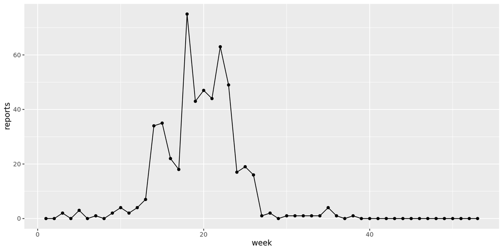

sim_sir(c(Beta=7.5,mu_IR=0.5,rho=0.5,k=10,eta=0.03,N=38000)) sim_sir(c(Beta=28,mu_IR=0.3,rho=0.5,k=10,eta=0.03,N=38000)) sim_sir(c(Beta=28,mu_IR=0.3,rho=0.5,k=10,eta=0.03,N=38000)) sim_sir(c(Beta=28,mu_IR=0.3,rho=0.55,k=500,eta=0.03,N=38000))

Simulation of POMP model for following parameters

| Parameter | $\beta$ | $\mu_{IR}$ | $\rho$ | $k$ | $\eta$ | $N$ |
| --- | --- | --- | --- | --- | --- | --- |
| Figure 1 | 7.5 | 0.5 | 0.5 | 10 | 0.03 | 38000 |
| Figure 2 | 28 | 0.3 | 0.5 | 10 | 0.03 | 38000 |
| Figure 3 | 28 | 0.3 | 0.5 | 10 | 0.03 | 38000 |
| Figure 4 | 28 | 0.3 | 0.55 | 500 | 0.03 | 38000 |

Based on the previous result from slides, I increase the value of $\beta$ so that we have more reports. Then I slightly decrease the $\mu_IR$ so that the peak won’t come so quickly. In the end, I changed the parameters for report gerneraton so that there is no too much volatility.

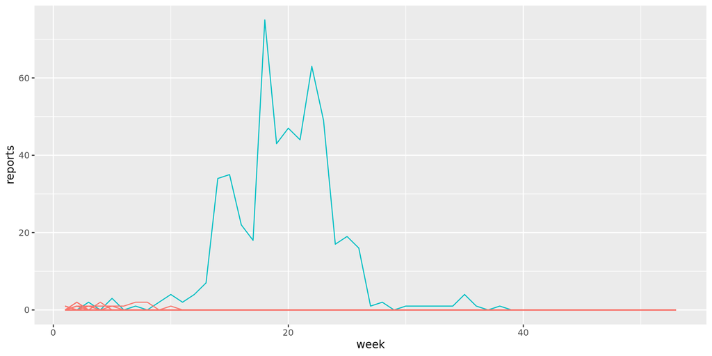

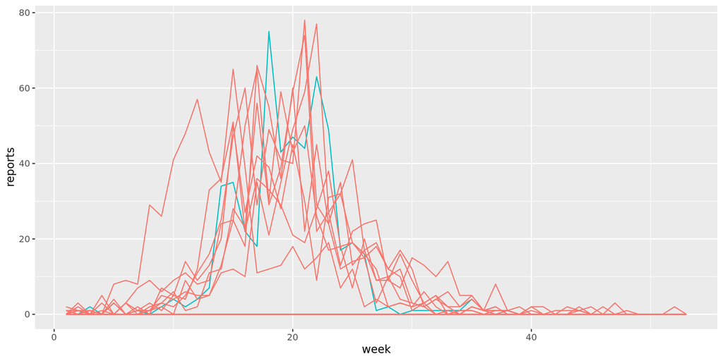

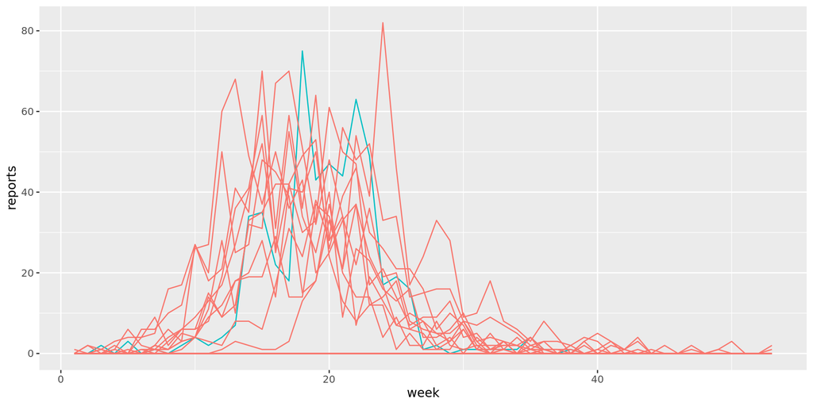

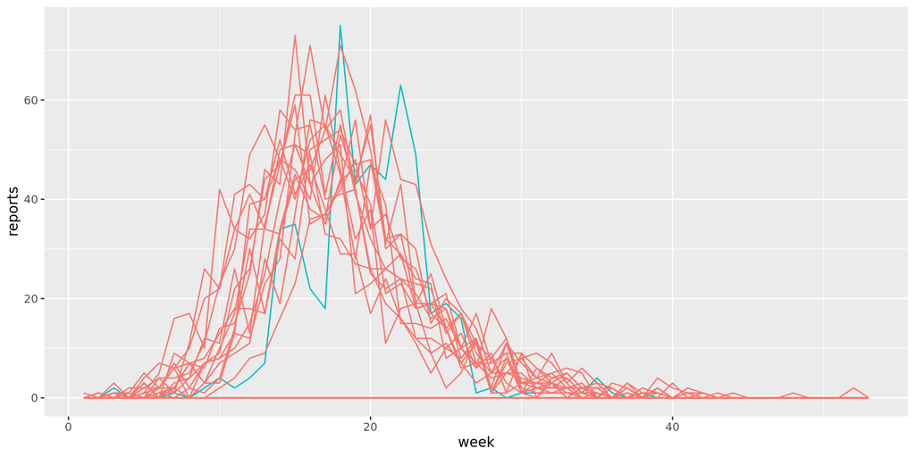

### 6.2

Simulation of POMP model for following parameters.

| Parameter | $\beta$ | $\mu_{IR}$ | $\rho$ | $k$ | $\eta$ | $N$ | $\mu_{EI}$ |
| --- | --- | --- | --- | --- | --- | --- | --- |
| Figure 1 | 28 | 0.3 | 0.55 | 500 | 0.03 | 38000 | 0.5 |
| Figure 2 | 40 | 0.35 | 0.5 | 500 | 0.03 | 38000 | 0.9 |

Firstly, I starts with the parameters from previous question and setting the transition rate from exposed to infectious $\mu_{EI}$ to be 0.5. The result is not good enough because the peak is low and coming too late. What’s more, there are too much noise after the peak. Therefore, I tuned the parameters of $\mu_{EI},\mu_{IR},\rho$ to make it better.

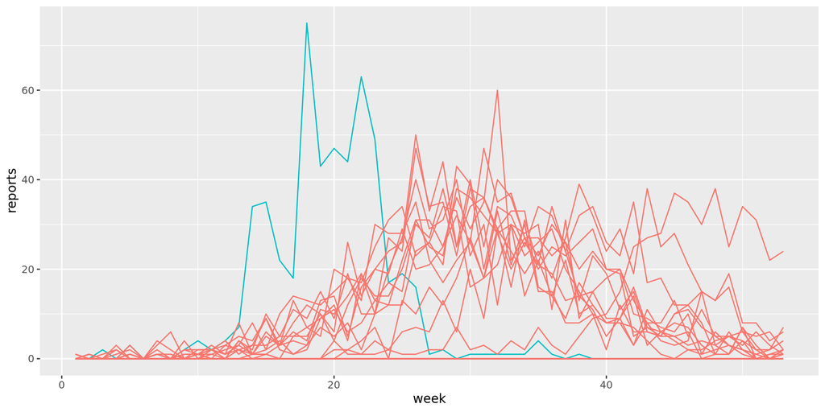

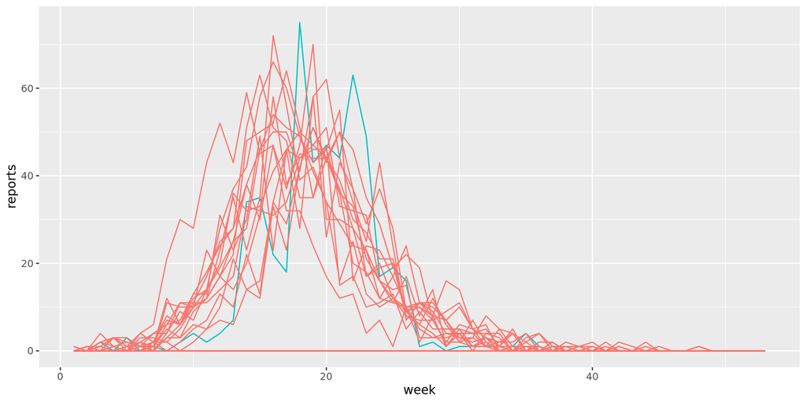

### Refernce

- [Slides about Chapter 12](https://ionides.github.io/531w22/12/index.html)
- [Compartmental models in epidemiology](https://en.wikipedia.org/wiki/Compartmental_models_in_epidemiology)
- [Previous Solution](https://ionides.github.io/531w21/hw06/sol06.html)